# XML Schema 1.0

# XML Schema 2.1

Schema version 2.1 includes all changes introduced with the first amendment of EU Regulation 2017/2400. The following parameters are mandatory:

- ZeroEmissionVehicle
- VocationalVehicle
- SleeperCab
- NgTankSystem (only for vehicles with natural gas as fuel type)
- ADAS Parameters (advanced driver assistant system): Engine Stop/Start, EcoRoll without engine stop, EcoRoll with engine stop, Predictive CruiseControl

Introduction of a new Vehicle type: Exempted vehicles. No VECTO simulation is performed for such vehicles.

## VehicleDeclarationType

[figure not shown]

## ExemptedVehicleDeclarationType

[figure not shown]

## AdvancedDriverAssistantSystemsType

[figure not shown]

## EngineDataDeclarationType

[figure not shown]

# XML Schema 2.3

- Introduction of a new model parameter for ADAS in combination with AT transmisisons: ATEcoRollReleaseLockupClutch
- New Engine component data:
  - Adding model parameters for WHR systems: WHR Type, electrical and/or mechanical WHR Power
  - Adding support for dual fuel engines, adding support for dual mode engines
- New gearbox component data: adding parameter whether Differential (axlegear) is included in the loss-map (required for FWD vehicles)

## AdvancedDriverAssistantSystemsType

[figure not shown]

## EngineDataDeclarationType

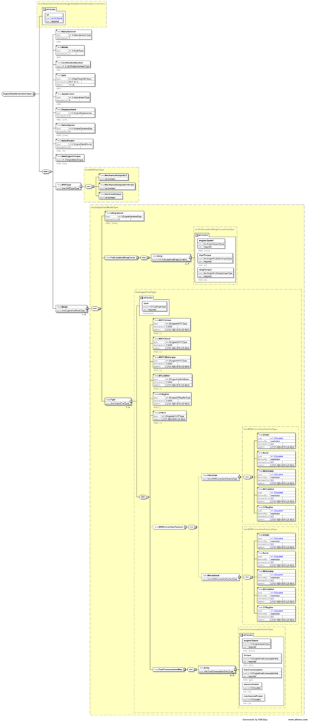

## GearboxDataDeclarationType

[figure not shown]

# XML Schema 2.6

- New Vehicle type: Heavy Bus Primary Vehicle
- New Vehiclee type: Heavy Bus Completed Vehicle

## PrimaryVehicleDeclarationType

[figure not shown]

## PrimaryVehicleComponentsDeclarationType

[figure not shown]

## PrimaryVehicleAuxiliairesDataDeclarationType

[figure not shown]

## CompletedVehicleDeclarationType

[figure not shown]

## CompletedVehicleComponentsDeclarationType

[figure not shown]

## CompletedVehicleAuxiliariesDataDeclarationType

[figure not shown]

# XML Schema Primary Vehicle Information File

VECTO Output generated for primary vehicles (heavy bus). Used as input for the second stage simulation.

## VectoOutputPrimaryVehicle

[figure not shown]

## PrimaryVehicleHeavyBusDataType

[figure not shown]

## VehiclePIFType

[figure not shown]

## VehicleComponentsPIFType

[figure not shown]

## EngineDataPIFType

[figure not shown]

## TransmissionDataPIFType

[figure not shown]

## TransmissionGearsPIFType

[figure not shown]

## AngledriveDataPIFType

[figure not shown]

## AxlegearDataPIFType

[figure not shown]